# Linear Mixed-Effects Models

Nick Freeland, Bernice Green, Gary Marmon

# Introduction

## Simple Linear Regressions

- assumes independence of observations
- slopes and intercepts measure average trends

# But…

What if the observations are not independent?

What if trends vary between clusters?

## Linear Mixed-Effects Models (LMMs)

- LMMs can be used to model correlated data
  - Cross sectional data: individuals nested in a geographical or social context - *ex: Student test data compared across Geometry classes*
  - Longitudinal data: repeated measures of individuals - *ex: Student test data over time*

Main application for mixed-effect models is in psychology due to the nature of their data and repeated observations across trial participants

## Fixed vs. Random Effects

- Fixed effects show average trends for the population
- Random effects show how trends vary across groups
  - explains error due to differences between groups

## Fixed and Random Effects

- mixed-effects models simultaneously model fixed and random effects
- fixed effect parameters
  - small number of clusters, large number of observations
- random effect parameters
  - large number of clusters, small number of clusters per observation

**It’s important to include the random effects in the model since fixed effects only give a partial picture of hierarchical data**

## Linear Model vs Linear Mixed-Effects Model

# Methods

- lme4 package has become the predominant tool in the R language for fitting linear mixed-effect models
- a linear mixed model is described by the distribution of two vector-valued random variables: $Y$, the response, and $\beta$, the vector of random effects
- Our basic model:
  $$epa = plays + (1+plays|coach)$$

# Data

Our data featured a play by play analysis for every game in the 2021 season.

| Variable | Meaning |
| --- | --- |
| pbp.posteam | the team with possession of the ball (offense) |
| pbp.posteam_type | specifies if the possessing team is home or away |
| pbp.game_id | the specific game id from the NFL |
| week | week number in the season that the game was played |
| season_type | flag that specifies if it is a regular (0) or post (1) season game |
| home_adv | flag that specifies home (0) or away(1) |
| coach | the coach of the team with possession (offensive plays) |
| opp_coach | the coach of the opposing team (defensive plays) |
| plays | total number of rush and pass plays given the team and game |
| pass_plays | number of pass plays given the team and game |
| pass_pct | the percentage of pass plays in the game calculated by pass_plays/plays |
| yards_gained | yards gained by an offense |
| shotgun_snaps | number of snaps a team lined up in a shotgun formation |
| ho_huddle_snaps | number of snaps a team used a no huddle offense |
| EPA_per_play | the mean of all pass and rush plays given team and game |

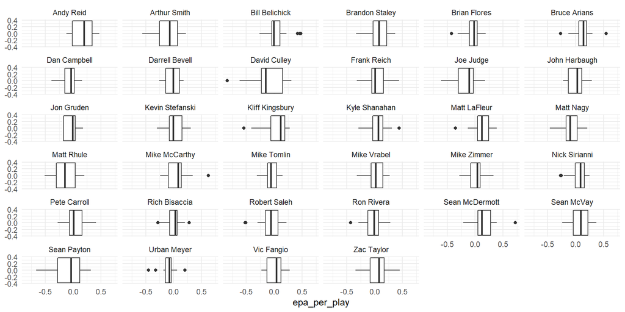

```r
# Compare EPA by coach
ggplot(team_sum2, aes(epa_per_play)) +
  geom_boxplot() +
  facet_wrap(~ coach) +
  theme_minimal()
```

# Analysis

```r
# LMM - random intercepts
epa.lmer1 = lmer(epa_per_play ~ pass_pct + plays + yards_gained + no_huddle_snap +
(1|coach) + (1|home_adv), data=team_sum2)

epa.lmer1
```

```
Linear mixed model fit by REML ['lmerModLmerTest']
Formula: epa_per_play ~ pass_pct + plays + yards_gained + no_huddle_snap +
    (1 | coach) + (1 | home_adv)
   Data: team_sum2
REML criterion at convergence: -657.5259
Random effects:
 Groups   Name        Std.Dev.
 coach    (Intercept) 0.02138
 home_adv (Intercept) 0.00000
 Residual             0.12358
Number of obs: 536, groups:  coach, 34; home_adv, 2
Fixed Effects:
   (Intercept)        pass_pct           plays    yards_gained  no_huddle_snap
     -0.065738       -0.360035       -0.005792        0.001993       -0.002185
optimizer (nloptwrap) convergence code: 0 (OK) ; 0 optimizer warnings; 1 lme4 warnings
```

-home advantage random effect approaches zero - no additional change in EPA per play due to home field advantage -additional 0.02 EPA per play due to coaching

```r
# LMM - random slopes
epa.lmer2 = lmer(epa_per_play ~ pass_pct + plays + yards_gained + shotgun_snaps + no_huddle_snap +
(1+pass_pct|coach) + (1+plays|coach) + (1+yards_gained|coach) + (1+shotgun_snaps|coach) + (1+no_huddle_snap|coach), data=team_sum2)
```

```r
# Testing for significance between models with and without home field advantage
epa.lmer2.null = lmer(epa_per_play ~ pass_pct + plays + yards_gained + shotgun_snaps + no_huddle_snap +
                  (1+pass_pct|coach) + (1+plays|coach) + (1+yards_gained|coach) + (1+shotgun_snaps|coach) + (1+no_huddle_snap|coach),                                            data=team_sum2,
                  REML=FALSE)

epa.lmer2.full = lmer(epa_per_play ~ home_adv + pass_pct + plays + yards_gained + shotgun_snaps + no_huddle_snap +
                  (1+home_adv|coach) + (1+pass_pct|coach) + (1+plays|coach) + (1+yards_gained|coach) + (1+shotgun_snaps|coach) + (1+no_huddle_snap|coach),                       data=team_sum2,
                  REML=FALSE)

anova(epa.lmer2.full, epa.lmer2.null)
```

```
Data: team_sum2
Models:
epa.lmer2.null: epa_per_play ~ pass_pct + plays + yards_gained + shotgun_snaps + no_huddle_snap + (1 + pass_pct | coach) + (1 + plays | coach) + (1 + yards_gained | coach) + (1 + shotgun_snaps | coach) + (1 + no_huddle_snap | coach)
epa.lmer2.full: epa_per_play ~ home_adv + pass_pct + plays + yards_gained + shotgun_snaps + no_huddle_snap + (1 + home_adv | coach) + (1 + pass_pct | coach) + (1 + plays | coach) + (1 + yards_gained | coach) + (1 + shotgun_snaps | coach) + (1 + no_huddle_snap | coach)
               npar     AIC     BIC logLik deviance  Chisq Df Pr(>Chisq)
epa.lmer2.null   22 -668.99 -574.74 356.50  -712.99
epa.lmer2.full   26 -663.43 -552.04 357.72  -715.43 2.4394  4     0.6555
```

- no statistical significance between the models -the effect of home field advantage is minimal to zero

# Conclusion